# LME Inter-Item Timing (winsorized)

Tyler Peckenpaugh

3/5/2019

# Inter-item timing analyses

Mean inter-reading time (IRT) is a measure of the amount of time in ms between when a subject stops speaking during a cold reading and when they begin speaking for a previewed reading.

Subjects were asked to read each sentence twice, once with no preview at all, and then again after unlimited preview. IRT is meant to represent their chosen preview time for the second reading.

## Mean and SD of IRT by condition

Mean inter-reading time (IRT) in ms

|  | mean |
| --- | --- |
| -GP -Q | 1090.041 |
| -GP +Q | 1189.157 |
| +GP -Q | 1221.706 |
| +GP +Q | 1229.504 |

Standard deviation inter-reading time (IRT) in ms

|  | -Q | +Q |
| --- | --- | --- |
| -GP | 1155.331 | 1079.879 |
| +GP | 1290.811 | 1246.087 |

## boxplot of mean inter-item time by condition

Inter reading time (IRT) in ms

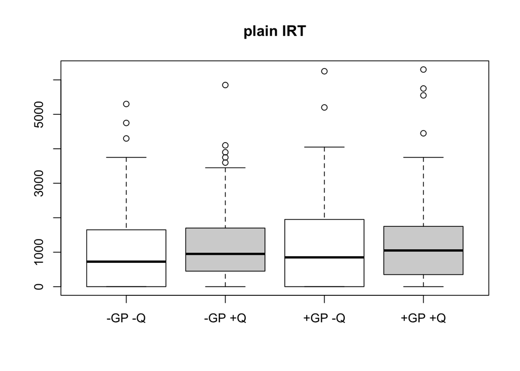

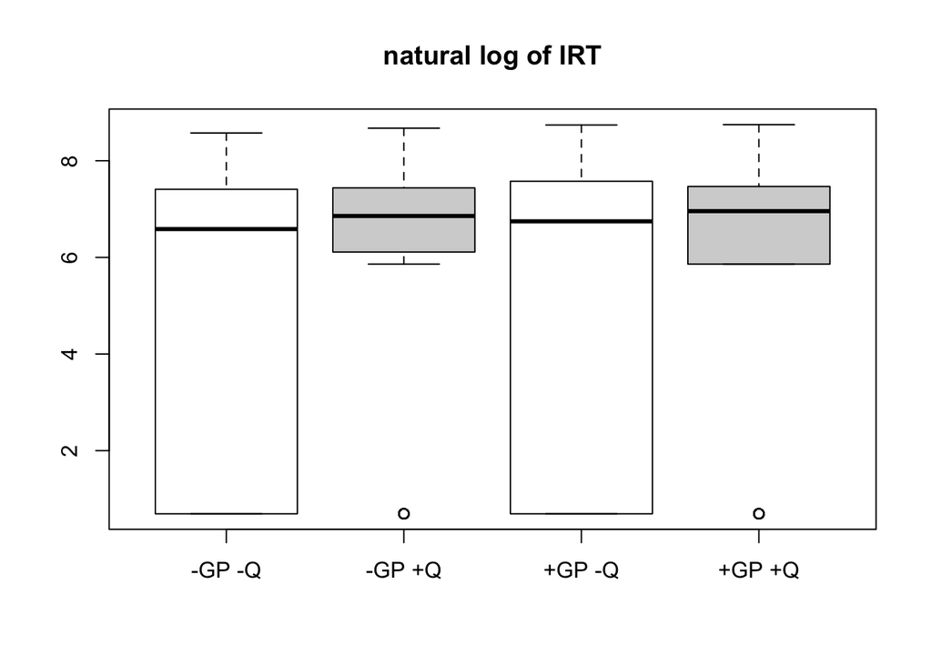

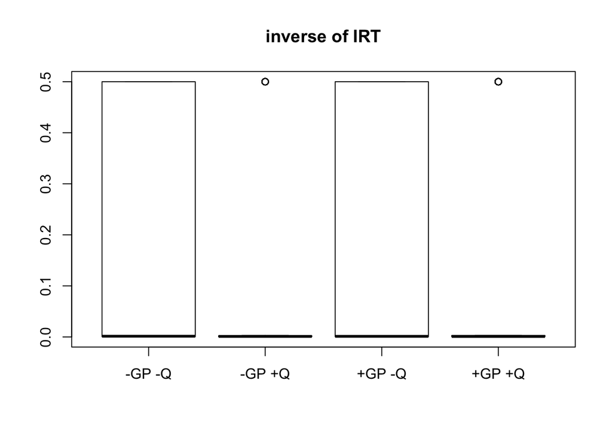

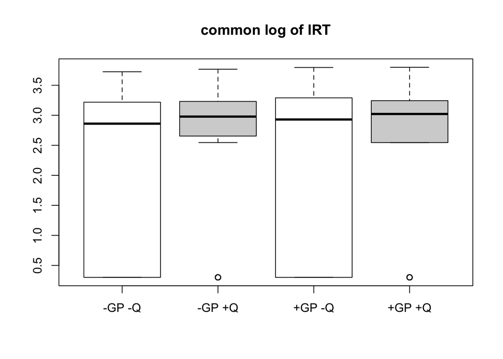

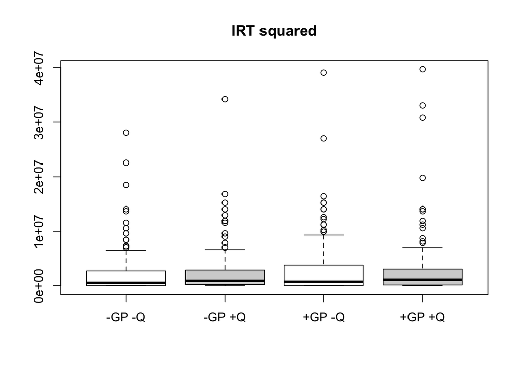

# Models

## All participants

### Full model

```r
summary(models.timing)
```

```
## Linear mixed model fit by maximum likelihood . t-tests use
##   Satterthwaite's method [lmerModLmerTest]
## Formula: inter_reading ~ GP_condition * Q_condition + (1 + GP_condition *
##     Q_condition | participant) + (1 + GP_condition * Q_condition |
##     item)
##    Data: inter_item_timings
## Control: lmerControl(optCtrl = list(maxfun = 2e+12))
##
##      AIC      BIC   logLik deviance df.resid
##   8426.2   8531.4  -4188.1   8376.2      473
##
## Scaled residuals:
##     Min      1Q  Median      3Q     Max
## -2.2668 -0.6091 -0.1856  0.4302  4.6358
##
## Random effects:
##  Groups      Name                             Variance Std.Dev. Corr
##  participant (Intercept)                      431559    656.93
##              GP_conditionTRUE                  19942    141.22   0.83
##              Q_conditionTRUE                    8330     91.27  -0.97
##              GP_conditionTRUE:Q_conditionTRUE 191392    437.48  -0.32
##  item        (Intercept)                       11669    108.02
##              GP_conditionTRUE                  72355    268.99  -1.00
##              Q_conditionTRUE                   62797    250.59  -1.00
##              GP_conditionTRUE:Q_conditionTRUE  65413    255.76   1.00
##  Residual                                     999921    999.96
##
##
##
##  -0.67
##  -0.80  0.09
##
##
##   1.00
##  -1.00 -1.00
##
## Number of obs: 498, groups:  participant, 33; item, 16
##
## Fixed effects:
##                                  Estimate Std. Error      df t value
## (Intercept)                       1097.92     148.58   33.07   7.389
## GP_conditionTRUE                   159.84     145.98   23.82   1.095
## Q_conditionTRUE                    110.01     142.42   27.22   0.772
## GP_conditionTRUE:Q_conditionTRUE  -133.11     205.49   27.78  -0.648
##                                  Pr(>|t|)
## (Intercept)                      1.71e-08 ***
## GP_conditionTRUE                    0.284
## Q_conditionTRUE                     0.447
## GP_conditionTRUE:Q_conditionTRUE    0.522
## ---
## Signif. codes:  0 '***' 0.001 '**' 0.01 '*' 0.05 '.' 0.1 ' ' 1
##
## Correlation of Fixed Effects:
##             (Intr) GP_cTRUE Q_TRUE
## GP_cndtTRUE -0.355
## Q_cndtnTRUE -0.552  0.585
## GP_TRUE:Q_T  0.233 -0.733   -0.684
## convergence code: 0
## singular fit
```

### Full model (natural log)

```r
summary(models.timingLn)
```

```
## Linear mixed model fit by maximum likelihood . t-tests use
##   Satterthwaite's method [lmerModLmerTest]
## Formula:
## inter_reading.ln ~ GP_condition * Q_condition + (1 + GP_condition *
##     Q_condition | participant) + (1 + GP_condition * Q_condition |
##     item)
##    Data: inter_item_timings
## Control: lmerControl(optCtrl = list(maxfun = 2e+12))
##
##      AIC      BIC   logLik deviance df.resid
##   2432.7   2538.0  -1191.4   2382.7      473
##
## Scaled residuals:
##     Min      1Q  Median      3Q     Max
## -2.4739 -0.4411  0.2696  0.6287  2.0267
##
## Random effects:
##  Groups      Name                             Variance Std.Dev. Corr
##  participant (Intercept)                      3.3324   1.8255
##              GP_conditionTRUE                 0.6457   0.8035   -1.00
##              Q_conditionTRUE                  0.4934   0.7024   -1.00
##              GP_conditionTRUE:Q_conditionTRUE 1.5879   1.2601    1.00
##  item        (Intercept)                      0.1070   0.3271
##              GP_conditionTRUE                 1.5697   1.2529   -1.00
##              Q_conditionTRUE                  0.3746   0.6120   -1.00
##              GP_conditionTRUE:Q_conditionTRUE 2.0074   1.4168    1.00
##  Residual                                     6.0564   2.4610
##
##
##
##   1.00
##  -1.00 -1.00
##
##
##   1.00
##  -1.00 -1.00
##
## Number of obs: 498, groups:  participant, 33; item, 16
##
## Fixed effects:
##                                  Estimate Std. Error      df t value
## (Intercept)                        5.1371     0.3975 32.9120  12.924
## GP_conditionTRUE                   0.1740     0.4646 15.4863   0.375
## Q_conditionTRUE                    0.6604     0.3689 30.5212   1.790
## GP_conditionTRUE:Q_conditionTRUE  -0.3859     0.6076 18.5746  -0.635
##                                  Pr(>|t|)
## (Intercept)                      1.92e-14 ***
## GP_conditionTRUE                   0.7130
## Q_conditionTRUE                    0.0833 .
## GP_conditionTRUE:Q_conditionTRUE   0.5331
## ---
## Signif. codes:  0 '***' 0.001 '**' 0.01 '*' 0.05 '.' 0.1 ' ' 1
##
## Correlation of Fixed Effects:
##             (Intr) GP_cTRUE Q_TRUE
## GP_cndtTRUE -0.650
## Q_cndtnTRUE -0.692  0.671
## GP_TRUE:Q_T  0.616 -0.850   -0.798
## convergence code: 0
## singular fit
```

### Full model (common log)

```r
summary(models.timingLg10)
```

```
## Linear mixed model fit by maximum likelihood . t-tests use
##   Satterthwaite's method [lmerModLmerTest]
## Formula:
## inter_reading.log10 ~ GP_condition * Q_condition + (1 + GP_condition *
##     Q_condition | participant) + (1 + GP_condition * Q_condition |
##     item)
##    Data: inter_item_timings
## Control: lmerControl(optCtrl = list(maxfun = 2e+12))
##
##      AIC      BIC   logLik deviance df.resid
##   1602.0   1707.3   -776.0   1552.0      473
##
## Scaled residuals:
##     Min      1Q  Median      3Q     Max
## -2.4677 -0.4431  0.2717  0.6258  2.0137
##
## Random effects:
##  Groups      Name                             Variance Std.Dev. Corr
##  participant (Intercept)                      0.63388  0.7962
##              GP_conditionTRUE                 0.12875  0.3588   -0.98
##              Q_conditionTRUE                  0.09587  0.3096   -1.00
##              GP_conditionTRUE:Q_conditionTRUE 0.30161  0.5492    1.00
##  item        (Intercept)                      0.01825  0.1351
##              GP_conditionTRUE                 0.28071  0.5298   -1.00
##              Q_conditionTRUE                  0.06486  0.2547   -1.00
##              GP_conditionTRUE:Q_conditionTRUE 0.35316  0.5943    1.00
##  Residual                                     1.14161  1.0685
##
##
##
##   0.99
##  -0.99 -1.00
##
##
##   1.00
##  -1.00 -1.00
##
## Number of obs: 498, groups:  participant, 33; item, 16
##
## Fixed effects:
##                                  Estimate Std. Error       df t value
## (Intercept)                       2.23080    0.17273 32.01114  12.915
## GP_conditionTRUE                  0.07589    0.19988 14.83951   0.380
## Q_conditionTRUE                   0.28694    0.15931 31.74283   1.801
## GP_conditionTRUE:Q_conditionTRUE -0.16776    0.26094 19.22259  -0.643
##                                  Pr(>|t|)
## (Intercept)                      3.07e-14 ***
## GP_conditionTRUE                   0.7096
## Q_conditionTRUE                    0.0812 .
## GP_conditionTRUE:Q_conditionTRUE   0.5279
## ---
## Signif. codes:  0 '***' 0.001 '**' 0.01 '*' 0.05 '.' 0.1 ' ' 1
##
## Correlation of Fixed Effects:
##             (Intr) GP_cTRUE Q_TRUE
## GP_cndtTRUE -0.649
## Q_cndtnTRUE -0.692  0.666
## GP_TRUE:Q_T  0.615 -0.846   -0.795
## convergence code: 0
## singular fit
```

### Full model (inverse)

```r
summary(models.timingInv)
```

```
## Linear mixed model fit by maximum likelihood . t-tests use
##   Satterthwaite's method [lmerModLmerTest]
## Formula:
## inter_reading.inverse ~ GP_condition * Q_condition + (1 + GP_condition *
##     Q_condition | participant) + (1 + GP_condition * Q_condition |
##     item)
##    Data: inter_item_timings
## Control: lmerControl(optCtrl = list(maxfun = 2e+12))
##
##      AIC      BIC   logLik deviance df.resid
##   -122.1    -16.8     86.0   -172.1      473
##
## Scaled residuals:
##     Min      1Q  Median      3Q     Max
## -2.0986 -0.5997 -0.2774  0.5484  2.3930
##
## Random effects:
##  Groups      Name                             Variance  Std.Dev. Corr
##  participant (Intercept)                      0.0176234 0.13275
##              GP_conditionTRUE                 0.0069113 0.08313  -0.95
##              Q_conditionTRUE                  0.0032672 0.05716  -0.99
##              GP_conditionTRUE:Q_conditionTRUE 0.0135241 0.11629   1.00
##  item        (Intercept)                      0.0004797 0.02190
##              GP_conditionTRUE                 0.0093796 0.09685  -1.00
##              Q_conditionTRUE                  0.0014224 0.03772  -1.00
##              GP_conditionTRUE:Q_conditionTRUE 0.0121266 0.11012   1.00
##  Residual                                     0.0359819 0.18969
##
##
##
##   0.98
##  -0.96 -1.00
##
##
##   1.00
##  -1.00 -1.00
##
## Number of obs: 498, groups:  participant, 33; item, 16
##
## Fixed effects:
##                                   Estimate Std. Error        df t value
## (Intercept)                       0.154877   0.029382 32.168968   5.271
## GP_conditionTRUE                 -0.007489   0.037149 16.845154  -0.202
## Q_conditionTRUE                  -0.051380   0.027726 37.474659  -1.853
## GP_conditionTRUE:Q_conditionTRUE  0.026573   0.048285 20.112764   0.550
##                                  Pr(>|t|)
## (Intercept)                      8.89e-06 ***
## GP_conditionTRUE                   0.8426
## Q_conditionTRUE                    0.0718 .
## GP_conditionTRUE:Q_conditionTRUE   0.5881
## ---
## Signif. codes:  0 '***' 0.001 '**' 0.01 '*' 0.05 '.' 0.1 ' ' 1
##
## Correlation of Fixed Effects:
##             (Intr) GP_cTRUE Q_TRUE
## GP_cndtTRUE -0.685
## Q_cndtnTRUE -0.710  0.647
## GP_TRUE:Q_T  0.647 -0.854   -0.778
## convergence code: 0
## singular fit
```

### Full model (squared)

```r
summary(models.timingSq)
```

```
## Linear mixed model fit by maximum likelihood . t-tests use
##   Satterthwaite's method [lmerModLmerTest]
## Formula:
## inter_reading.sqred ~ GP_condition * Q_condition + (1 + GP_condition *
##     Q_condition | participant) + (1 + GP_condition * Q_condition |
##     item)
##    Data: inter_item_timings
## Control: lmerControl(optCtrl = list(maxfun = 2e+12))
##
##      AIC      BIC   logLik deviance df.resid
##  16815.0  16920.3  -8382.5  16765.0      473
##
## Scaled residuals:
##     Min      1Q  Median      3Q     Max
## -1.8721 -0.3978 -0.2043  0.0618  6.9331
##
## Random effects:
##  Groups      Name                             Variance  Std.Dev. Corr
##  participant (Intercept)                      3.821e+12 1954726
##              GP_conditionTRUE                 2.042e+12 1428937   0.77
##              Q_conditionTRUE                  1.618e+09   40227   0.97
##              GP_conditionTRUE:Q_conditionTRUE 8.329e+12 2885994  -0.49
##  item        (Intercept)                      1.158e+11  340286
##              GP_conditionTRUE                 2.278e+11  477250  -0.83
##              Q_conditionTRUE                  6.918e+11  831754  -0.98
##              GP_conditionTRUE:Q_conditionTRUE 2.331e+11  482771  -0.18
##  Residual                                     2.094e+13 4576342
##
##
##
##   0.90
##  -0.73 -0.60
##
##
##   0.93
##  -0.40 -0.02
##
## Number of obs: 498, groups:  participant, 33; item, 16
##
## Fixed effects:
##                                    Estimate Std. Error         df t value
## (Intercept)                      2574274.51  543774.64      33.98   4.734
## GP_conditionTRUE                  743834.93  644525.64      33.80   1.154
## Q_conditionTRUE                    79770.23  616734.45      40.13   0.129
## GP_conditionTRUE:Q_conditionTRUE -313128.10  972574.66      32.49  -0.322
##                                  Pr(>|t|)
## (Intercept)                       3.8e-05 ***
## GP_conditionTRUE                    0.257
## Q_conditionTRUE                     0.898
## GP_conditionTRUE:Q_conditionTRUE    0.750
## ---
## Signif. codes:  0 '***' 0.001 '**' 0.01 '*' 0.05 '.' 0.1 ' ' 1
##
## Correlation of Fixed Effects:
##             (Intr) GP_cTRUE Q_TRUE
## GP_cndtTRUE -0.328
## Q_cndtnTRUE -0.558  0.494
## GP_TRUE:Q_T  0.164 -0.697   -0.567
## convergence code: 0
## singular fit
```

```r
summary(models.timingNoInt)
```

```
## Linear mixed model fit by maximum likelihood . t-tests use
##   Satterthwaite's method [lmerModLmerTest]
## Formula: inter_reading ~ GP_condition * Q_condition + (1 + GP_condition *
##     Q_condition | participant) + (1 + GP_condition * Q_condition |
##     item)
##    Data: inter_item_timings
## Control: lmerControl(optCtrl = list(maxfun = 2e+12))
##
##      AIC      BIC   logLik deviance df.resid
##   8426.2   8531.4  -4188.1   8376.2      473
##
## Scaled residuals:
##     Min      1Q  Median      3Q     Max
## -2.2668 -0.6091 -0.1856  0.4302  4.6358
##
## Random effects:
##  Groups      Name                             Variance Std.Dev. Corr
##  participant (Intercept)                      431559    656.93
##              GP_conditionTRUE                  19942    141.22   0.83
##              Q_conditionTRUE                    8330     91.27  -0.97
##              GP_conditionTRUE:Q_conditionTRUE 191392    437.48  -0.32
##  item        (Intercept)                       11669    108.02
##              GP_conditionTRUE                  72355    268.99  -1.00
##              Q_conditionTRUE                   62797    250.59  -1.00
##              GP_conditionTRUE:Q_conditionTRUE  65413    255.76   1.00
##  Residual                                     999921    999.96
##
##
##
##  -0.67
##  -0.80  0.09
##
##
##   1.00
##  -1.00 -1.00
##
## Number of obs: 498, groups:  participant, 33; item, 16
##
## Fixed effects:
##                                  Estimate Std. Error      df t value
## (Intercept)                       1097.92     148.58   33.07   7.389
## GP_conditionTRUE                   159.84     145.98   23.82   1.095
## Q_conditionTRUE                    110.01     142.42   27.22   0.772
## GP_conditionTRUE:Q_conditionTRUE  -133.11     205.49   27.78  -0.648
##                                  Pr(>|t|)
## (Intercept)                      1.71e-08 ***
## GP_conditionTRUE                    0.284
## Q_conditionTRUE                     0.447
## GP_conditionTRUE:Q_conditionTRUE    0.522
## ---
## Signif. codes:  0 '***' 0.001 '**' 0.01 '*' 0.05 '.' 0.1 ' ' 1
##
## Correlation of Fixed Effects:
##             (Intr) GP_cTRUE Q_TRUE
## GP_cndtTRUE -0.355
## Q_cndtnTRUE -0.552  0.585
## GP_TRUE:Q_T  0.233 -0.733   -0.684
## convergence code: 0
## singular fit
```

## Only “gp-sensitive”

The following models exclude all participants whose mean inter-item reading time for `+GP` items is less than for `-GP` items

```r
summary(models.timing.Sense)
```

[output not shown]

### Without interaction

```r
summary(models.timingNoInt.Sense)
```

```
## Linear mixed model fit by maximum likelihood . t-tests use
##   Satterthwaite's method [lmerModLmerTest]
## Formula: inter_reading ~ GP_condition + Q_condition + (1 + GP_condition +
##     Q_condition | participant) + (1 + GP_condition + Q_condition |
##     item)
##    Data: subset(inter_item_timings, !(participant %in% gpInsensitive))
## Control: lmerControl(optCtrl = list(maxfun = 2e+12))
##
##      AIC      BIC   logLik deviance df.resid
##   5011.5   5070.5  -2489.7   4979.5      279
##
## Scaled residuals:
##     Min      1Q  Median      3Q     Max
## -1.9779 -0.5572 -0.1723  0.4167  4.2391
##
## Random effects:
##  Groups      Name             Variance Std.Dev. Corr
##  participant (Intercept)       677300   823.0
##              GP_conditionTRUE   27019   164.4   -0.43
##              Q_conditionTRUE    74730   273.4   -0.74  0.92
##  item        (Intercept)            0     0.0
##              GP_conditionTRUE   23171   152.2    NaN
##              Q_conditionTRUE    26290   162.1    NaN  1.00
##  Residual                     1044826  1022.2
## Number of obs: 295, groups:  participant, 20; item, 16
##
## Fixed effects:
##                  Estimate Std. Error      df t value Pr(>|t|)
## (Intercept)       1197.92     211.92   18.94   5.653 1.91e-05 ***
## GP_conditionTRUE   240.86     131.16   32.11   1.836   0.0756 .
## Q_conditionTRUE    -25.46     140.88   23.33  -0.181   0.8581
## ---
## Signif. codes:  0 '***' 0.001 '**' 0.01 '*' 0.05 '.' 0.1 ' ' 1
##
## Correlation of Fixed Effects:
##             (Intr) GP_TRU
## GP_cndtTRUE -0.366
## Q_cndtnTRUE -0.529  0.214
## convergence code: 0
## singular fit
```

# Checking assumptions

The following checks assumptions about the data

## Homogeneity of variance

Anova of squared residuals (full model) by participant. If the data fit the assumption, we expect no statistical significance.

### All Ps

```r
# all participants
anova(timings_sq_resid)
```

```
## Analysis of Variance Table
##
## Response: resids_main.sq
##              Df     Sum Sq    Mean Sq F value Pr(>F)
## participant   1 4.4826e+12 4.4826e+12  1.1547 0.2831
## Residuals   496 1.9255e+15 3.8822e+12
```

### All Ps (natural log)

```r
# all participants
anova(timings_sq_resid_ln)
```

```
## Analysis of Variance Table
##
## Response: resids_mainLn.sq
##              Df  Sum Sq Mean Sq F value  Pr(>F)
## participant   1   328.6  328.56  5.8075 0.01632 *
## Residuals   496 28061.1   56.57
## ---
## Signif. codes:  0 '***' 0.001 '**' 0.01 '*' 0.05 '.' 0.1 ' ' 1
```

### All Ps (squared)

```r
# all participants
anova(timings_sq_resid_sq)
```

```
## Analysis of Variance Table
##
## Response: resids_mainSq.sq
##              Df     Sum Sq    Mean Sq F value Pr(>F)
## participant   1 1.0338e+28 1.0338e+28    1.44 0.2307
## Residuals   496 3.5609e+30 7.1792e+27
```

### All Ps (inverse)

```r
# all participants
anova(timings_sq_resid_inv)
```

```
## Analysis of Variance Table
##
## Response: resids_mainInv.sq
##              Df  Sum Sq  Mean Sq F value   Pr(>F)
## participant   1 0.01613 0.016126  8.0751 0.004673 **
## Residuals   496 0.99051 0.001997
## ---
## Signif. codes:  0 '***' 0.001 '**' 0.01 '*' 0.05 '.' 0.1 ' ' 1
```

### All Ps (Log10)

```r
# all participants
anova(timings_sq_resid_log10)
```

```
## Analysis of Variance Table
##
## Response: resids_mainLg10.sq
##              Df Sum Sq Mean Sq F value  Pr(>F)
## participant   1  11.62 11.6169  5.7901 0.01648 *
## Residuals   496 995.15  2.0063
## ---
## Signif. codes:  0 '***' 0.001 '**' 0.01 '*' 0.05 '.' 0.1 ' ' 1
```

### Only GP-sense

```r
# GP-sensitive only
anova(sens_timings_sq_resid)
```

```
## Analysis of Variance Table
##
## Response: resids_main.sq
##              Df     Sum Sq    Mean Sq F value Pr(>F)
## participant   1 7.1817e+12 7.1817e+12  1.8057 0.1801
## Residuals   293 1.1654e+15 3.9773e+12
```

## Normal distribution of residuals

QQ plots of models with interation

### All participants

Outcome is plain IRT

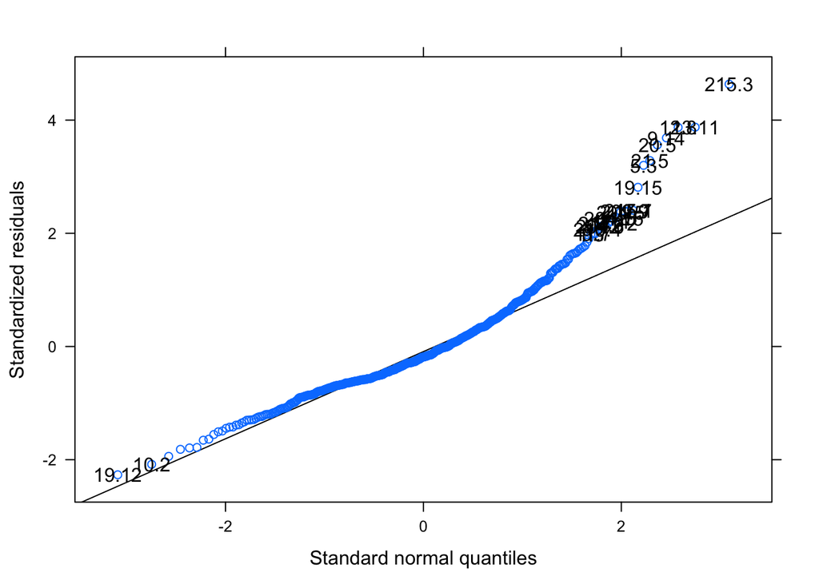

```r
qqmath(models.timing, id=0.05)
```

### All participants (Natural log)

Outcome is plain natural log of IRT

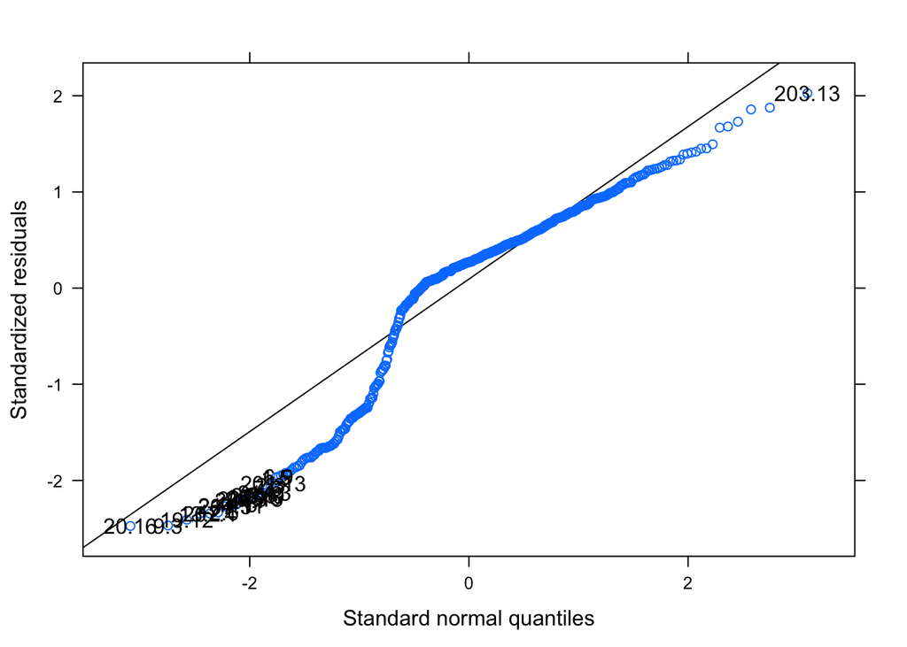

```r
qqmath(models.timingLn, id=0.05)
```

### All participants (Log 10)

Outcome is common log of IRT

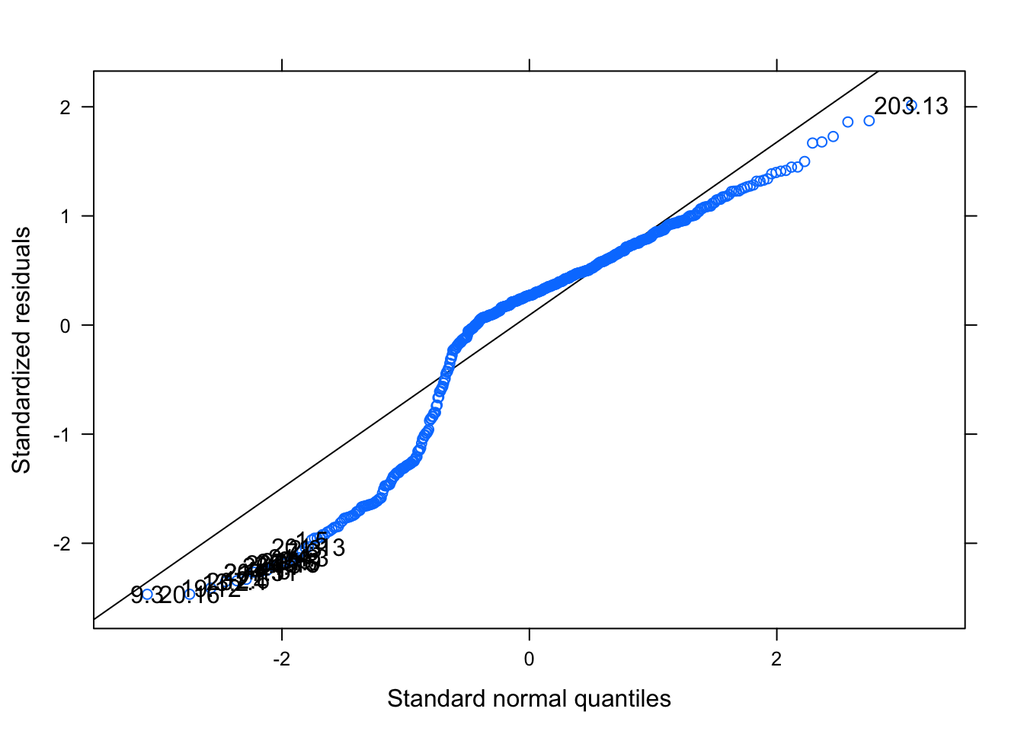

```r
qqmath(models.timingLg10, id=0.05)
```

### All participants (Inverse)

Outcome is inverse of IRT (i.e. 1/IRT)

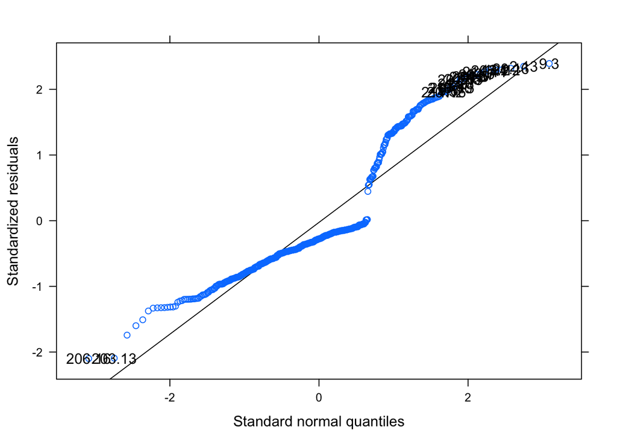

```r
qqmath(models.timingInv, id=0.05)
```

### All participants (Squared)

Outcome is IRT squared

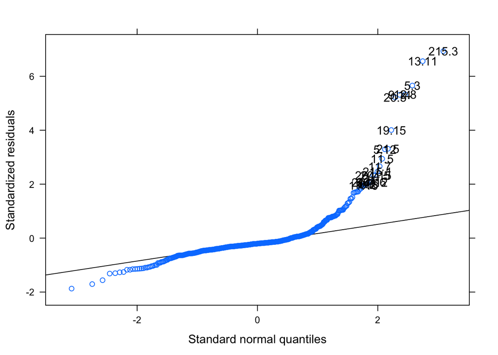

```r
qqmath(models.timingSq, id=0.05)
```

### Only GP-sensitive participants

Outcome is plain IRT, but uses subset of participants sensitive to GP

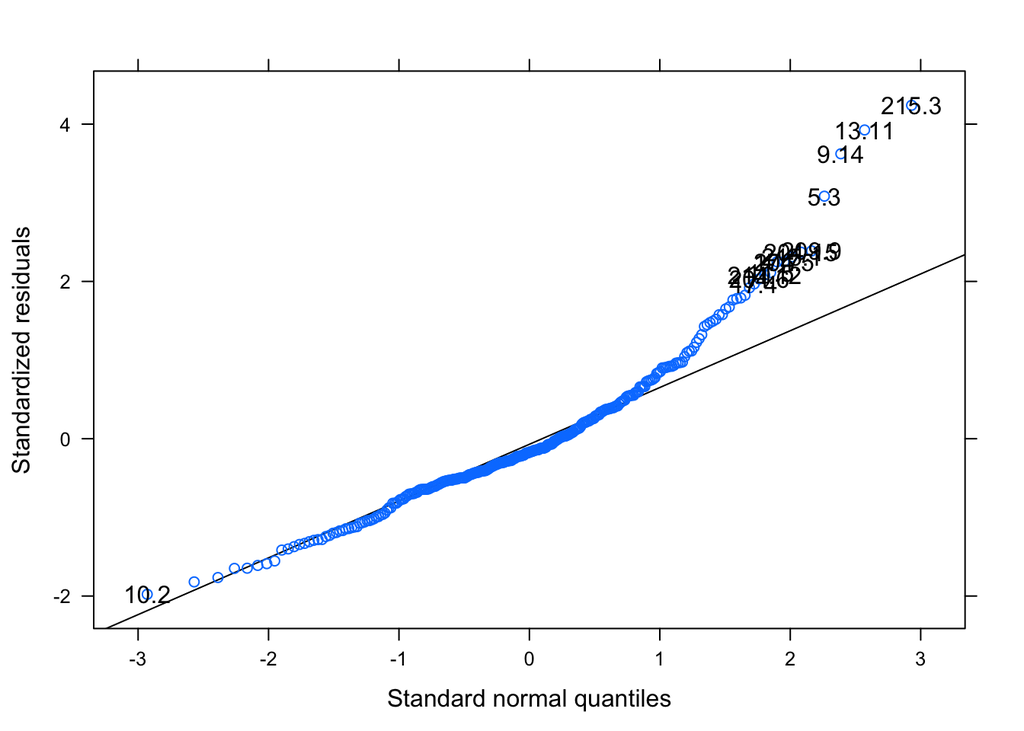

```r
qqmath(models.timing.Sense, id=0.05)
```

## Linearity

Plots of residuals vs. observed

### All Ps

Plain IRT

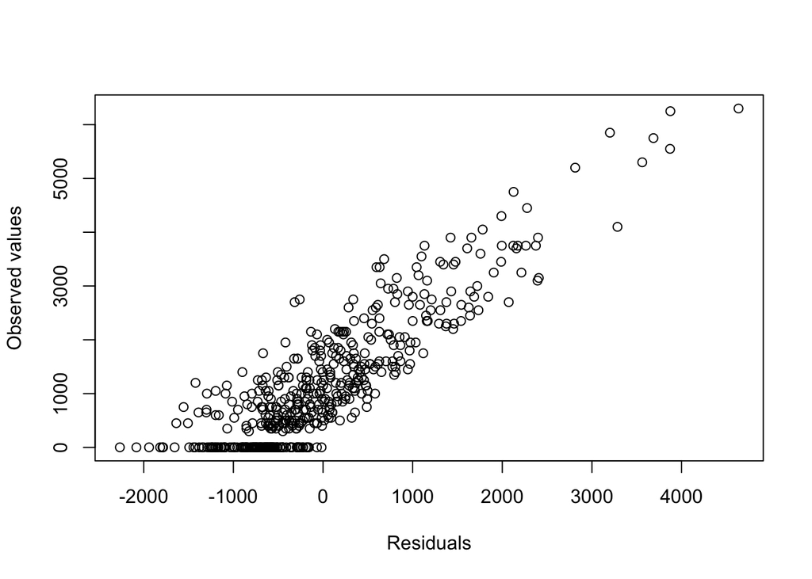

```r
plot(resid(models.timing),na.omit(inter_item_timings$inter_reading),xlab="Residuals",ylab="Observed values")
```

### All Ps (nautral log)

Natural log of IRT

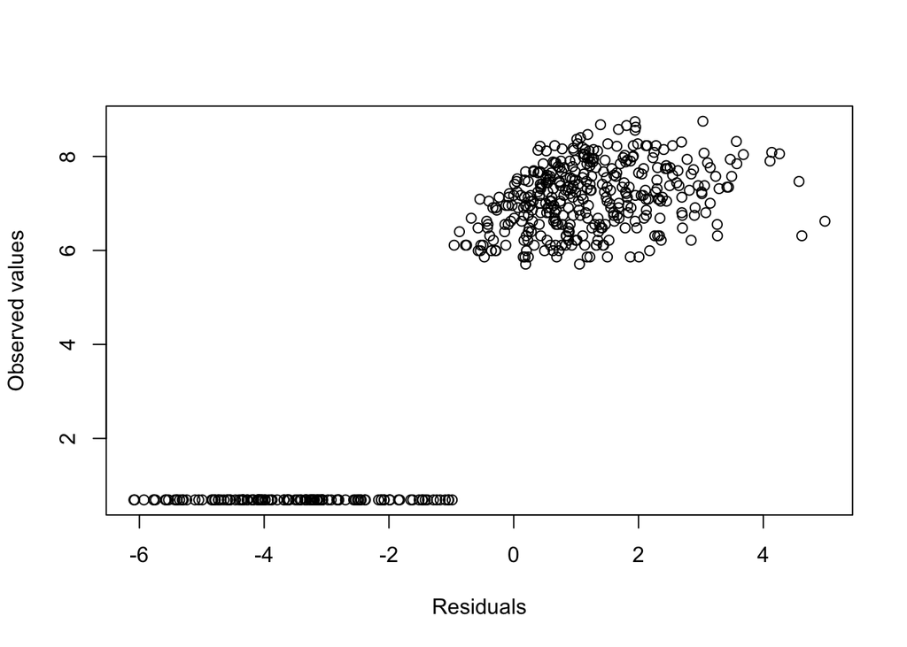

```r
plot(resid(models.timingLn),na.omit(inter_item_timings$inter_reading.ln),xlab="Residuals",ylab="Observed values")
```

### All Ps (log10)

Common log of IRT

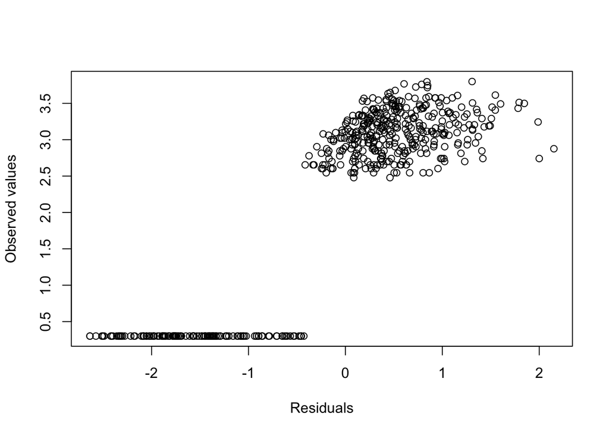

```r
plot(resid(models.timingLg10),na.omit(inter_item_timings$inter_reading.log10),xlab="Residuals",ylab="Observed values")
```

### All Ps (squared)

IRT squared

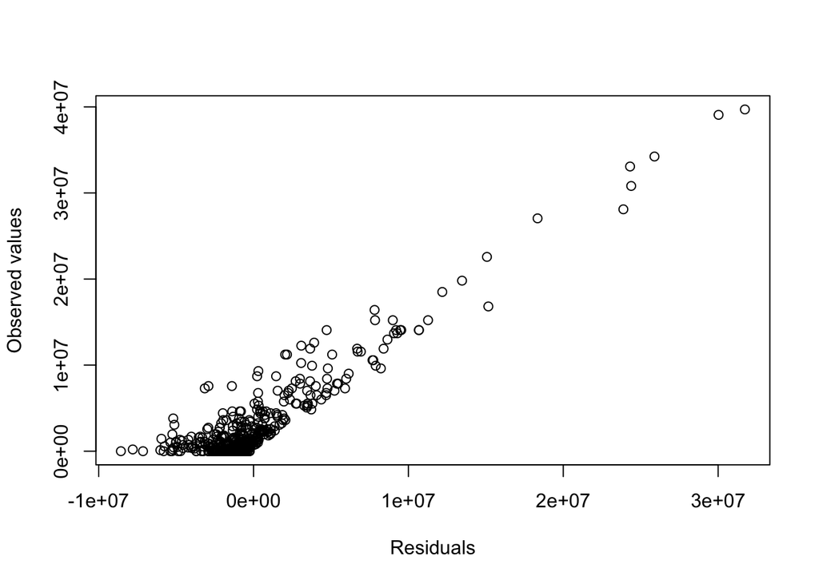

```r
plot(resid(models.timingSq),na.omit(inter_item_timings$inter_reading.sqred),xlab="Residuals",ylab="Observed values")
```

### All Ps (Inverse)

1/IRT

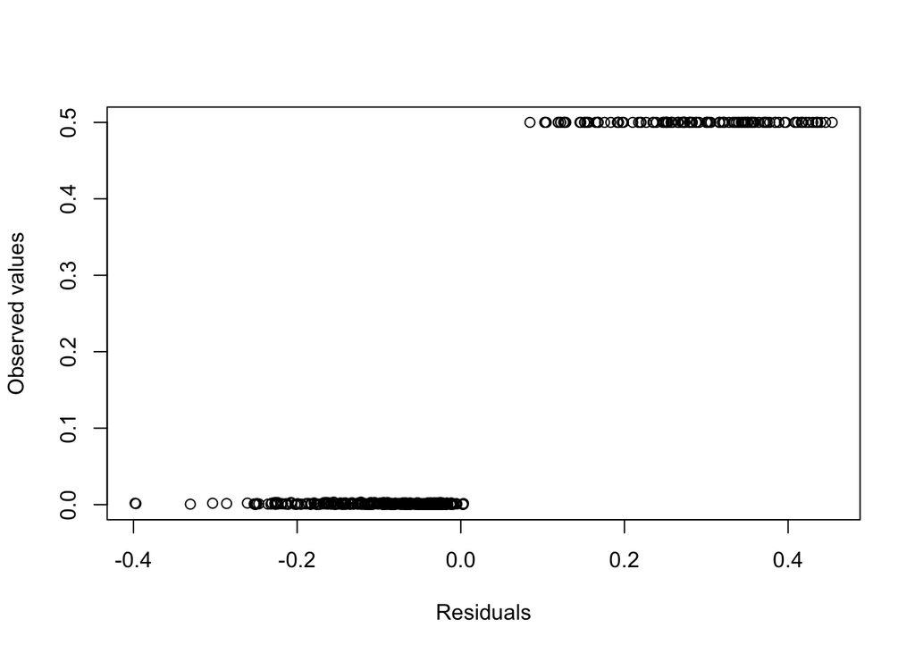

```r
plot(resid(models.timingInv),na.omit(inter_item_timings$inter_reading.inverse),xlab="Residuals",ylab="Observed values")
```

### GP-sensitive only

Subset of subjects sensitive to GP

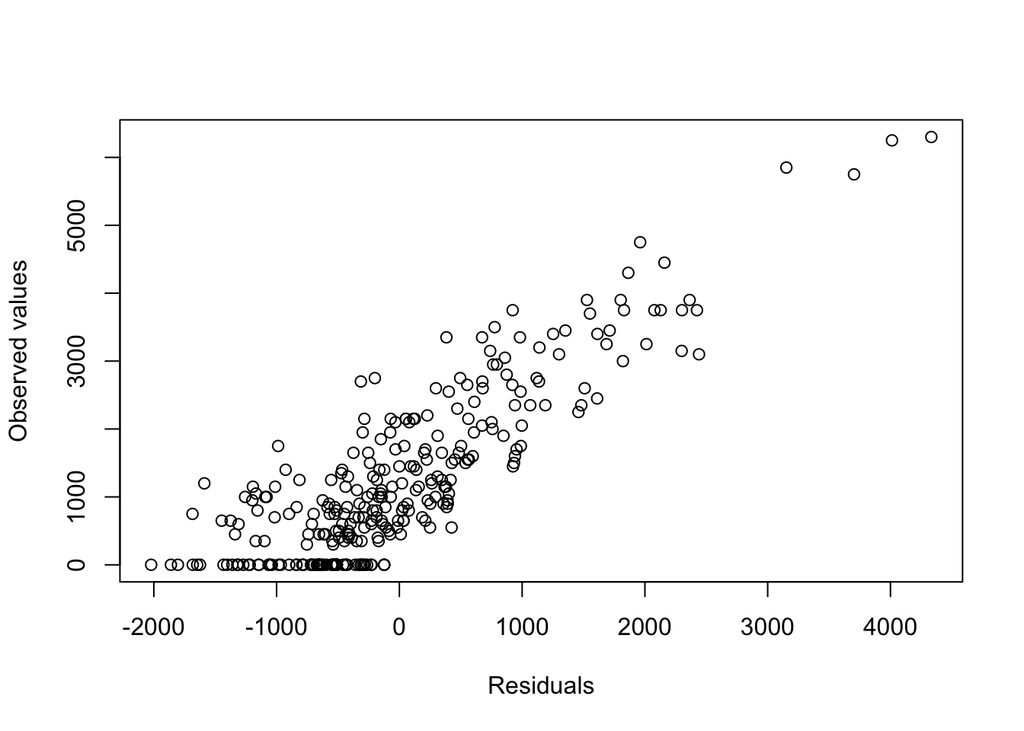

```r
plot(resid(models.timing.Sense),na.omit(sensitive_timings$inter_reading),xlab="Residuals",ylab="Observed values")
```